# graphs, line chart, scatter plot, bar cahrt, histogram,

# pie chart, stack plot, polar plot, boxplot, violin plot, count plot

# matrix plot, heatmap, acorr, angles sprectum, axes,axis,

# contour, draw, loglog, margins, text, title, triplot,

# limiting area, range, style, customization

# ----------------------------------------------------------------------------------------------------

```python
import pandas as pd
import numpy as np
import matplotlib.pyplot as plt
import seaborn as sns
```

```python
data1 = pd.read_csv('F:\excel\Sales.csv')
data2 = pd.read_excel('F:\excel\Orders list.xlsx')
data3 = pd.read_csv(r'F:\excel\city_temperature.csv', low_memory=False)
```

```python
data3.drop('State', axis=1, inplace=True)
```

```python
data5 = data1[1000:1500]
data6 = data3[0:1000]
data4 = data3[(data3['City'] == 'Algiers') & (data3['Month'] == 1) & (data3['Year'] == 1995) ]
```

```python
data1.head()
```

|  | Date | Day | Month | Year | Customer_Age | Age_Group | Customer_Gender | Country | State | Product_Category | Sub_Category | Product | Order_Quantity | Unit_Cost | Unit_Price | Profit | Cost | Revenue |
| --- | --- | --- | --- | --- | --- | --- | --- | --- | --- | --- | --- | --- | --- | --- | --- | --- | --- | --- |
| 0 | 2013-11-26 | 26 | November | 2013 | 19 | Youth (<25) | M | Canada | British Columbia | Accessories | Bike Racks | Hitch Rack - 4-Bike | 8 | 45 | 120 | 590 | 360 | 950 |
| 1 | 2015-11-26 | 26 | November | 2015 | 19 | Youth (<25) | M | Canada | British Columbia | Accessories | Bike Racks | Hitch Rack - 4-Bike | 8 | 45 | 120 | 590 | 360 | 950 |
| 2 | 2014-03-23 | 23 | March | 2014 | 49 | Adults (35-64) | M | Australia | New South Wales | Accessories | Bike Racks | Hitch Rack - 4-Bike | 23 | 45 | 120 | 1366 | 1035 | 2401 |
| 3 | 2016-03-23 | 23 | March | 2016 | 49 | Adults (35-64) | M | Australia | New South Wales | Accessories | Bike Racks | Hitch Rack - 4-Bike | 20 | 45 | 120 | 1188 | 900 | 2088 |
| 4 | 2014-05-15 | 15 | May | 2014 | 47 | Adults (35-64) | F | Australia | New South Wales | Accessories | Bike Racks | Hitch Rack - 4-Bike | 4 | 45 | 120 | 238 | 180 | 418 |

```python
data2.head()
```

|  | Order | Order Date | Order Quantity | Sales | Ship Mode | Profit | Unit Price | Customer Name | Customer Segment | Product Category |
| --- | --- | --- | --- | --- | --- | --- | --- | --- | --- | --- |
| 0 | 3 | 2010-10-13 | 6 | 261.5400 | Regular Air | -213.250 | 38.94 | Muhammed MacIntyre | Small Business | Office Supplies |
| 1 | 6 | 2012-02-20 | 2 | 6.9300 | Regular Air | -4.640 | 2.08 | Ruben Dartt | Corporate | Office Supplies |
| 2 | 32 | 2011-07-15 | 26 | 2808.0800 | Regular Air | 1054.820 | 107.53 | Liz Pelletier | Corporate | Furniture |
| 3 | 32 | 2011-07-15 | 24 | 1761.4000 | Delivery Truck | -1748.560 | 70.89 | Liz Pelletier | Corporate | Furniture |
| 4 | 32 | 2011-07-15 | 23 | 160.2335 | Regular Air | -85.129 | 7.99 | Liz Pelletier | Corporate | Technology |

```python
data3.head()
```

|  | Region | Country | City | Month | Day | Year | AvgTemperature |
| --- | --- | --- | --- | --- | --- | --- | --- |
| 0 | Africa | Algeria | Algiers | 1 | 1 | 1995 | 64.2 |
| 1 | Africa | Algeria | Algiers | 1 | 2 | 1995 | 49.4 |
| 2 | Africa | Algeria | Algiers | 1 | 3 | 1995 | 48.8 |
| 3 | Africa | Algeria | Algiers | 1 | 4 | 1995 | 46.4 |
| 4 | Africa | Algeria | Algiers | 1 | 5 | 1995 | 47.9 |

```python
data4.head()
```

|  | Region | Country | City | Month | Day | Year | AvgTemperature |
| --- | --- | --- | --- | --- | --- | --- | --- |
| 0 | Africa | Algeria | Algiers | 1 | 1 | 1995 | 64.2 |
| 1 | Africa | Algeria | Algiers | 1 | 2 | 1995 | 49.4 |
| 2 | Africa | Algeria | Algiers | 1 | 3 | 1995 | 48.8 |
| 3 | Africa | Algeria | Algiers | 1 | 4 | 1995 | 46.4 |
| 4 | Africa | Algeria | Algiers | 1 | 5 | 1995 | 47.9 |

```python
data5
```

|  | Date | Day | Month | Year | Customer_Age | Age_Group | Customer_Gender | Country | State | Product_Category | Sub_Category | Product | Order_Quantity | Unit_Cost | Unit_Price | Profit | Cost | Revenue |
| --- | --- | --- | --- | --- | --- | --- | --- | --- | --- | --- | --- | --- | --- | --- | --- | --- | --- | --- |
| 1000 | 2014-07-20 | 20 | July | 2014 | 51 | Adults (35-64) | M | United States | California | Accessories | Bike Stands | All-Purpose Bike Stand | 4 | 59 | 159 | 387 | 236 | 623 |
| 1001 | 2016-07-20 | 20 | July | 2016 | 51 | Adults (35-64) | M | United States | California | Accessories | Bike Stands | All-Purpose Bike Stand | 1 | 59 | 159 | 97 | 59 | 156 |
| 1002 | 2013-10-20 | 20 | October | 2013 | 45 | Adults (35-64) | F | Australia | New South Wales | Accessories | Bike Stands | All-Purpose Bike Stand | 3 | 59 | 159 | 238 | 177 | 415 |
| 1003 | 2015-10-20 | 20 | October | 2015 | 45 | Adults (35-64) | F | Australia | New South Wales | Accessories | Bike Stands | All-Purpose Bike Stand | 4 | 59 | 159 | 317 | 236 | 553 |
| 1004 | 2013-12-23 | 23 | December | 2013 | 35 | Adults (35-64) | F | Canada | British Columbia | Accessories | Bike Stands | All-Purpose Bike Stand | 2 | 59 | 159 | 197 | 118 | 315 |
| ... | ... | ... | ... | ... | ... | ... | ... | ... | ... | ... | ... | ... | ... | ... | ... | ... | ... | ... |
| 1495 | 2013-12-13 | 13 | December | 2013 | 31 | Young Adults (25-34) | M | Canada | British Columbia | Accessories | Bottles and Cages | Water Bottle - 30 oz. | 27 | 2 | 5 | 80 | 54 | 134 |
| 1496 | 2015-12-13 | 13 | December | 2015 | 31 | Young Adults (25-34) | M | Canada | British Columbia | Accessories | Bottles and Cages | Water Bottle - 30 oz. | 22 | 2 | 5 | 65 | 44 | 109 |
| 1497 | 2015-12-13 | 13 | December | 2015 | 31 | Young Adults (25-34) | M | Canada | British Columbia | Accessories | Bottles and Cages | Water Bottle - 30 oz. | 29 | 2 | 5 | 86 | 58 | 144 |
| 1498 | 2013-12-24 | 24 | December | 2013 | 31 | Young Adults (25-34) | M | Canada | British Columbia | Accessories | Bottles and Cages | Water Bottle - 30 oz. | 3 | 2 | 5 | 9 | 6 | 15 |
| 1499 | 2013-12-24 | 24 | December | 2013 | 31 | Young Adults (25-34) | M | Canada | British Columbia | Accessories | Bottles and Cages | Water Bottle - 30 oz. | 8 | 2 | 5 | 24 | 16 | 40 |

500 rows × 18 columns

```python
data6.head()
```

|  | Region | Country | City | Month | Day | Year | AvgTemperature |
| --- | --- | --- | --- | --- | --- | --- | --- |
| 0 | Africa | Algeria | Algiers | 1 | 1 | 1995 | 64.2 |
| 1 | Africa | Algeria | Algiers | 1 | 2 | 1995 | 49.4 |
| 2 | Africa | Algeria | Algiers | 1 | 3 | 1995 | 48.8 |
| 3 | Africa | Algeria | Algiers | 1 | 4 | 1995 | 46.4 |
| 4 | Africa | Algeria | Algiers | 1 | 5 | 1995 | 47.9 |

# ------------------------------------------------------------------------------------------------------

# Possible values of palette are:

Accent, Accent_r, Blues, Blues_r, BrBG, BrBG_r, BuGn, BuGn_r, BuPu, BuPu_r, CMRmap, CMRmap_r, Dark2, Dark2_r,

GnBu, GnBu_r, Greens, Greens_r, Greys, Greys_r, OrRd, OrRd_r, Oranges, Oranges_r, PRGn, PRGn_r, Paired, Paired_r,

Pastel1, Pastel1_r, Pastel2, Pastel2_r, PiYG, PiYG_r, PuBu, PuBuGn, PuBuGn_r, PuBu_r, PuOr, PuOr_r, PuRd, PuRd_r,

Purples, Purples_r, RdBu, RdBu_r, RdGy, RdGy_r, RdPu, RdPu_r, RdYlBu, RdYlBu_r, RdYlGn, RdYlGn_r, Reds, Reds_r, Set1,

Set1_r, Set2, Set2_r, Set3, Set3_r, Spectral, Spectral_r, Wistia, Wistia_r, YlGn, YlGnBu, YlGnBu_r, YlGn_r, YlOrBr,

YlOrBr_r, YlOrRd, YlOrRd_r, afmhot, afmhot_r, autumn, autumn_r, binary, binary_r, bone, bone_r, brg, brg_r, bwr, bwr_r,

cividis, cividis_r, cool, cool_r, coolwarm, coolwarm_r, copper, copper_r, cubehelix, cubehelix_r, flag, flag_r, gist_earth,

# -----------------------------------------------------------------------------------------------------------

# seaborn box plot

seaborn box plot is very helpful to idnetify outlires form a data frame or a column. it takes int or float values.

boxplot can be plot using only x value or both x and y values

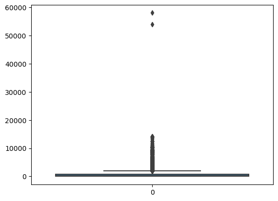

```python
sns.boxplot(data1['Revenue'])
plt.show()
```

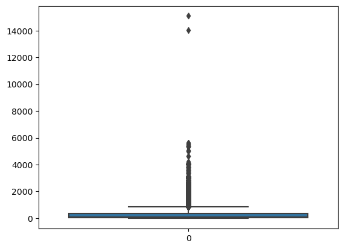

```python
sns.boxplot(data1['Profit'])
plt.show()
```

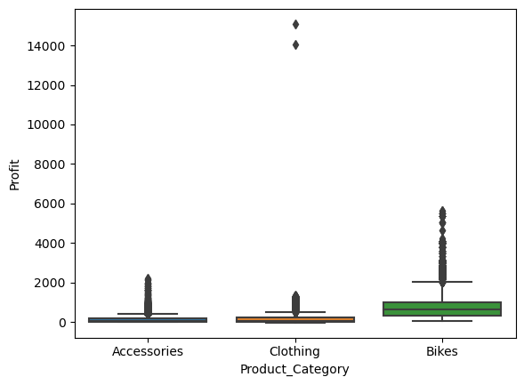

```python
sns.boxplot(x = "Product_Category", y = 'Profit', data=data1)
plt.show()
```

# seaborn histogram plot

# -----------------------------------------------------------------------------------------------

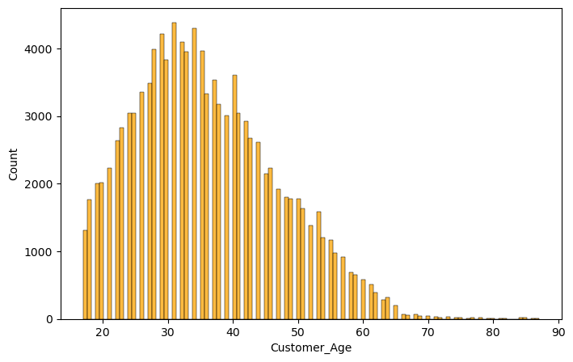

```python
plt.figure(figsize=(8,5))
sns.histplot(data1['Customer_Age'], color = 'orange')
plt.show()
```

# histogram whith line plot

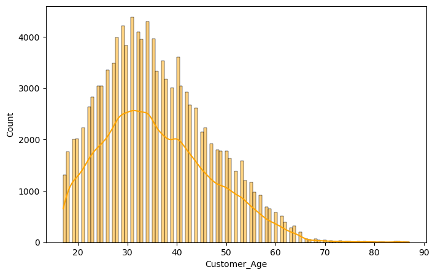

```python
plt.figure(figsize=(8,5))
sns.histplot(data1['Customer_Age'], kde=True, color = 'orange')
plt.show()
```

# seaborn scatter plot

# ---------------------------------------------------------------------------------------------------

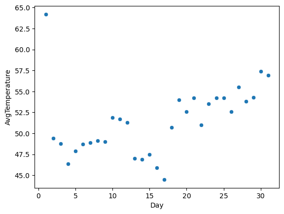

```python
sns.scatterplot(x = data4['Day'], y = data4['AvgTemperature'])
plt.show()
```

# seaborn scatter plot with fit of best line

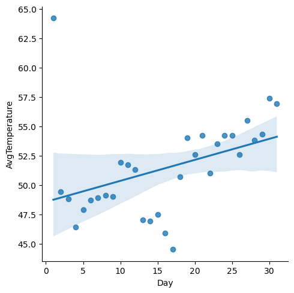

```python
sns.lmplot(x = 'Day', y = 'AvgTemperature', data=data4)
plt.show()
```

# seaborn scatter plot with multiple fit of best line

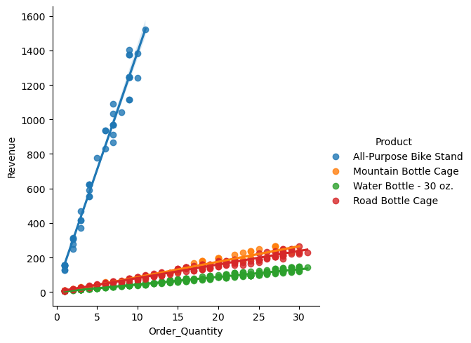

```python
sns.lmplot(x = 'Order_Quantity', y = 'Revenue', hue = 'Product', data = data5)
plt.show()
```

# seaborn scatter plot with matplotlib line plot

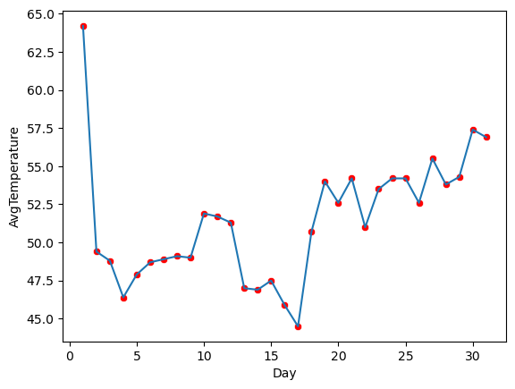

```python
sns.scatterplot(x = data4['Day'], y = data4['AvgTemperature'], color='red')
plt.plot('Day', 'AvgTemperature', data = data4)
plt.show()
```

# seaborn heatmap

# -------------------------------------------------------------------------------------------------------

Heatmap is defined as a graphical representation of data using colors to visualize the value of the matrix. In this, to represent more common values or higher activities brighter colors basically reddish colors are used and to represent less common or activity values, darker colors are preferred. Heatmap is also defined by the name of the shading matrix. Heatmaps in Seaborn can be plotted by using the seaborn.heatmap() function.

data: 2D dataset(matrix form) vmin, vmax: rage of correlation cmap: for coloring center: annot: True- if we want to show data of each box annot_kws = {'fontsize': , 'fontweight': bold/italic, } to change font size, color, style etc square = True - if we want to make each box a perfect square fmt: linewidths: linecolor: cbar:

```python
cost_vs_profit = data5[['Cost', 'Profit']].corr()
cost_vs_profit
```

|  | Cost | Profit |
| --- | --- | --- |
| Cost | 1.00000 | 0.98467 |
| Profit | 0.98467 | 1.00000 |

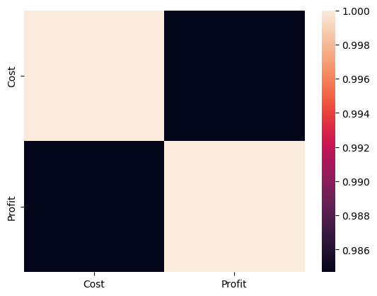

```python
sns.heatmap(cost_vs_profit)
plt.show()
```

```python
age_revenue = data5[['Customer_Age', 'Order_Quantity', 'Profit', 'Revenue']].corr()
age_revenue
```

|  | Customer_Age | Order_Quantity | Profit | Revenue |
| --- | --- | --- | --- | --- |
| Customer_Age | 1.000000 | -0.038279 | -0.039697 | -0.039280 |
| Order_Quantity | -0.038279 | 1.000000 | -0.033464 | -0.029583 |
| Profit | -0.039697 | -0.033464 | 1.000000 | 0.997311 |
| Revenue | -0.039280 | -0.029583 | 0.997311 | 1.000000 |

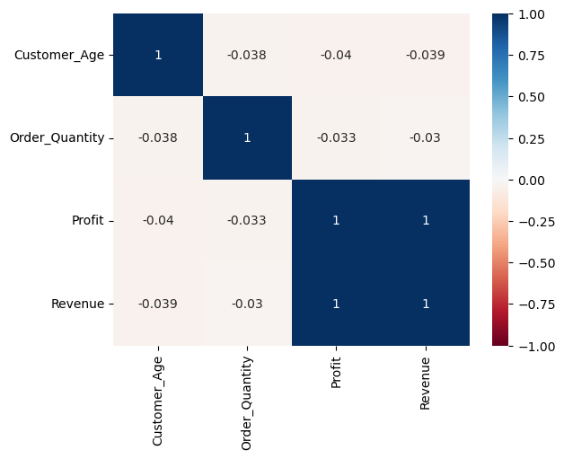

```python
sns.heatmap(age_revenue, cmap = 'RdBu', annot = True, vmin = -1, vmax = +1)
plt.show()
```

# seabrn pair plot

# --------------------------------------------------------------------------------------------------

# seaborn.pairplot(data, *, hue=None, hue_order=None, palette=None, vars=None, x_vars=None, y_vars=None, kind='scatter', diag_kind='auto', markers=None, height=2.5, aspect=1, corner=False, dropna=False, plot_kws=None, diag_kws=None, grid_kws=None, size=None)

hue: name of variable hue_order: list of strings palett: dict or seaborn color palette vars: list of variable names {x, y}_vars: lists of variable names kind: {‘scatter’, ‘kde’, ‘hist’, ‘reg’} diag_kind: {‘auto’, ‘hist’, ‘kde’, None} markers: single matplotlib marker code or list {plot, diag, grid}_kws: dicts

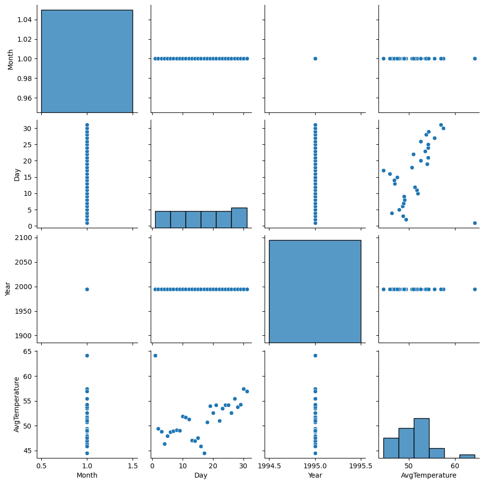

```python
sns.pairplot(data4)
plt.show()
```

# seaborn bar plot

# --------------------------------------------------------------------------------------------------------

# simple bar structure

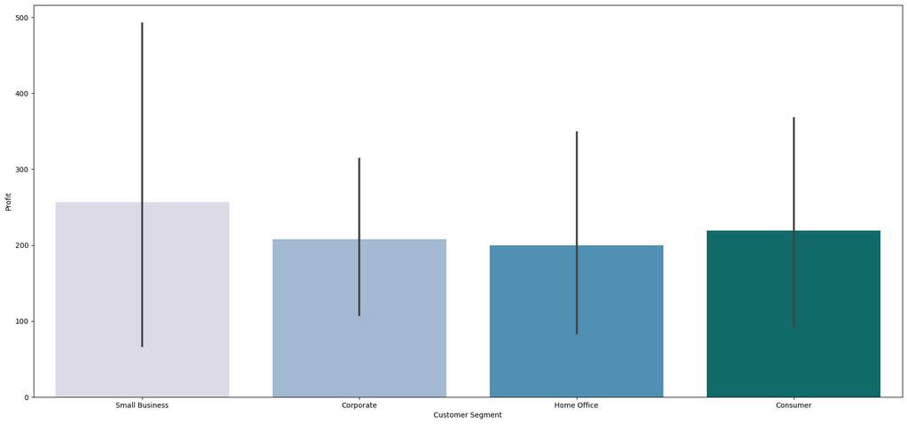

```python
plt.figure(figsize=(22,10))
sns.barplot(x = 'Customer Segment', y = 'Profit', data=data2, palette = 'PuBuGn')
plt.show()
```

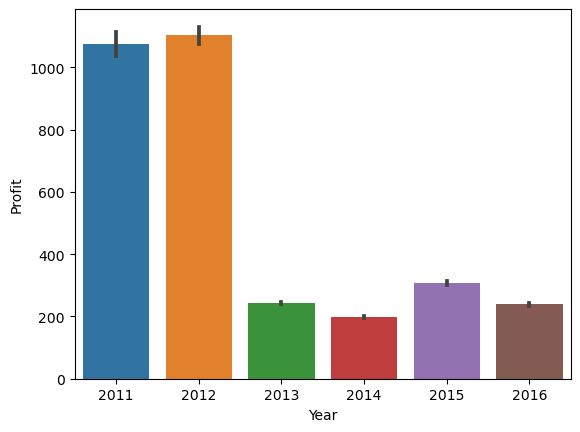

```python
sns.barplot(x = 'Year', y = 'Profit', data=data1)
plt.show()
```

# design the bar

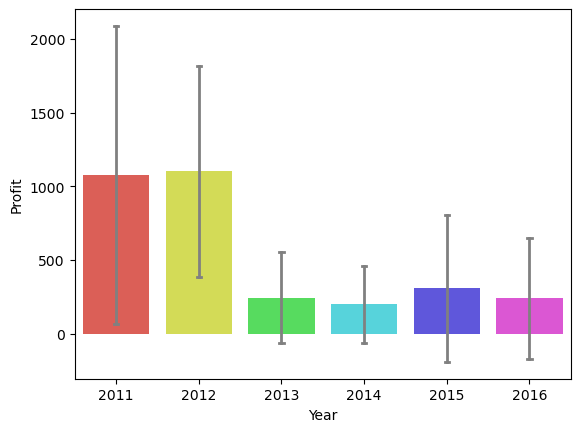

```python
sns.barplot(x = 'Year', y = 'Profit', data=data1, palette = 'hls', capsize = 0.05, saturation = 8,
            errcolor = 'gray', errwidth = 2, errorbar = 'sd')
plt.show()
```

# to delet box line use sns.despine()

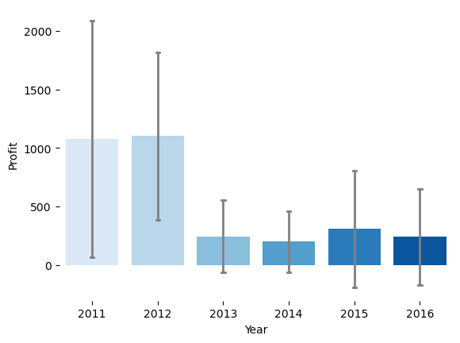

```python
sns.barplot(x = 'Year', y = 'Profit', data=data1, palette = 'Blues', capsize = 0.05, saturation = 8,
            errcolor = 'gray', errwidth = 2, errorbar = 'sd')
sns.despine(left = True, bottom = True)
plt.show()
```

# double bar

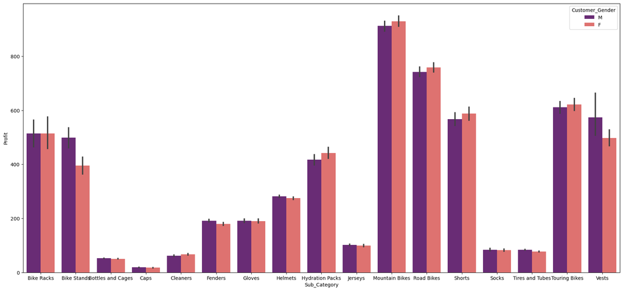

```python
plt.figure(figsize=(22,10))
sns.barplot(x = 'Sub_Category', y = 'Profit', hue='Customer_Gender', data=data1, palette = 'magma')
plt.show()
```

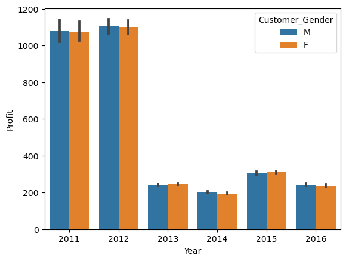

```python
sns.barplot(x = 'Year', y = 'Profit', hue = 'Customer_Gender', data=data1)
plt.show()
```

# multiple bar

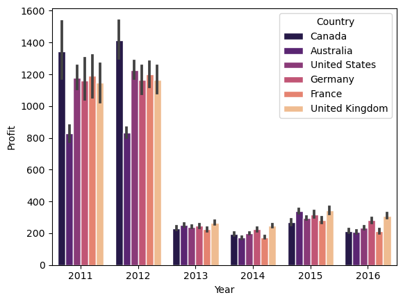

```python
sns.barplot(x = 'Year', y = 'Profit', hue = 'Country', data=data1,  palette = 'magma', edgecolor = 'w')
plt.show()
```

# seaborn countplot

# ----------------------------------------------------------------------------------------------------

seaborn.countplot() method is used to Show the counts of observations in each categorical bin using bars.

# basic structure of seaborn countplot

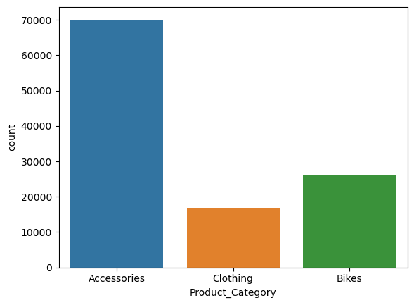

```python
sns.countplot(x = 'Product_Category', data=data1)
plt.show()
```

# horizontal count plot

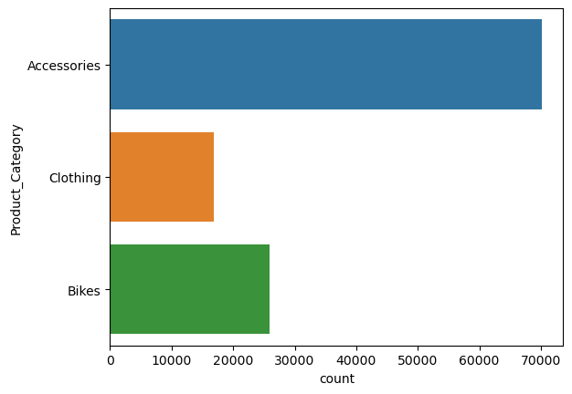

```python
#its very easy . just put x value into y and y valu into x-----------------------------

sns.countplot(y = 'Product_Category', data=data1)
plt.show()
```

# double count plot

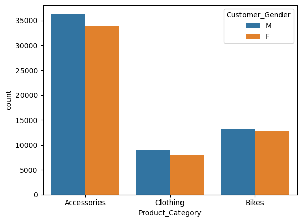

```python
sns.countplot(x = 'Product_Category', hue='Customer_Gender', data=data1)
plt.show()
```

# multiple count plot

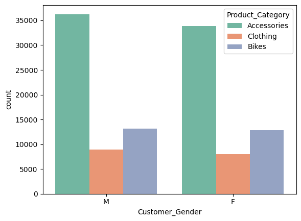

```python
sns.countplot(x = 'Customer_Gender', hue='Product_Category', data=data1, palette = "Set2")
plt.show()
```